# Projet Data Mining 2 - Analyse Econométrique du prix des diamands

```r
#Librairies----
library(ggplot2)
library(gplots)
library(dplyr)
library(corrplot)
library(factoextra)
library(FactoMineR)
library(questionr)
```

# **1. Introduction**

Traditionnellement, la présentation d’une bague en métal rare ornée d’une pierre précieuse à une personne, est emblématique du gage d’amour et d’engagement.

Cette pierre précieuse, reste aujourd’hui encore très majoritairement le diamant. L’indistrie du diamant connaît depuis le début de 20eme siècle un essor inégalée dans le monde des pierres précieuses. Son succès quant à lui peut en grande partie être expliquée par ses nombreuses caractéristiques tels que sa dûreté, sa pureté, son symbolisme, ses propriétés chimiiques, optiques, électriques et thermiques, ainsi que son prix.

En effet, le diamant reste une pierre coûteuse. La question que l’on va se poser n’est pas du pourquoi le prix, mais plutôt comment ce prix peut-il être expliqués par des caractéristiques objectives ?

Nous travaillerons dans cet étude de cas, sur un jeu de données contenant plusieurs caractéristiques et mesures de diamants.

Depuis le 1er Février 2020 le taux du livret A est descendu à son plus bas niveau : 0.5%. Intérêts et frais de gestion de compte sont alors quasi-similaires et le Livret A n’apparait donc plus comme un produit bancaire attractif et rentable aux yeux de nombreux Français. De plus, la fragilité et l’instabilité de l’économie mondiale rebutte nombre de personnes à faire confiance aux différentes banques. La tendance depuis plusieurs années est d’investir dans des biens immobiliers ou dans l’art pour placer ses économies “en sécurité” et surtout pouvoir faire de la plus-value dans le futur. Cependant, acheter une maison ou des tableaux a un coût et seules les personnes possédant déjà un patrimoine élevé peuvent se le permettre. Dans ce cas, quelles sont les options de placement accessibles aux bourses plus modestes ? Après avoir longuement réfléchi, ils nous est apparu que les pierres et métaux précieux sont toujours des options de placement intéressantes. Nous avons tous déjà entendu nos grands-parents dire que l’or est une valeur sûre, que son cours ne fait qu’augmenter depuis la guerre et qu’avoir toujours un peu d’or chez soi permet de se sortir de situations financières peu agréables. L’objet de notre étude n’est pas l’or, nous avons préféré nous pencher vers les pierres précieuses et notamment le Diamant. Qui n’a jamais rêvé d’avoir une belle bague ornée de diamants ou de personnaliser sa couronne dentaire avec un petit diamant incrusté (phéomène qui semble avoir été très à la mode chez certains rappeur Américains) ?

Finalement, nous proposons une étude statistique du prix des diamants en fonction de plusieurs variables afin de permettre aux futurs acheteurs de ne pas se faire arnaquer par des revendeurs peu scrupuleux et ainsi maximiser leur plus-value future.

# **2. La base de données**

Notre étude aura pour support une base de données “diamonds” disponible dans la librairie ggplot2 du logiciel Rstudio. Ce jeu de données est constitué de 53940 enregistrements et de 10 variables.

## *Description des variables:*

**carat** : variable quantitative représentant le poids d’un diamant en carat (1 carat=0.2 gramme)

**table** : variable quantitative représentant la largeur du sommet du diamant par rapport au point le plus large

**x** : variable quantitative représentant la longueur d’un diamant, en mm.

**y**: variable quantitative représentant la largeur d’un diamant, en mm.

**z**: variable quantitative représentant la profondeur d’un diamant, en mm.

```r
str(diamonds)
```

[output not shown]

On retrouve bien les 3 variables qualitatives cut, color et clarity avec leurs différentes modalités. Toutes les autres variables sont des variables quantitatives. On remarque que la colonne price est rangée par order croissant de prix. Il faudra tenir compte de cela lors de l’échantillonnage pour rester fidèle aux proportions des différentes modalités et prix du jeu de données initial.

```r
summary(diamonds)
```

[output not shown]

La variable **cut** met en évidence que dans ce jeu de données, il y a en majorité des diamants de coupe Ideal, puis de coupe Premium puis de coupe Very Good. Les coupes Good et Fair sont très peu représentées. Il faudra encore une fois faire attention à respecter les proportions lors de l’échantillonage. En revanche pour la variable **clarity**, ce sont les modalités représentant une qualité intermédiaire qui sont les plus représentées. Il semble y avoir peu de diamants de clarté IF et I1. La variable **color** semble être répartie de manière gaussienne, avec la couleur intermédiaire G la plus présente dans ce jeu de données.

Changons maintenant le nom des colonnes pour avoir plus de lisibilité :

```r
colnames(diamonds) <- c("carat",
                    "cut",
                    "color",
                    "clarity",
                    "fdepth",
                    "table",
                    "price",
                    "length",
                    "width",
                    "depth")
diamonds
```

| carat | cut | color | clarity | fdepth | table | price | length | width | depth |
| --- | --- | --- | --- | --- | --- | --- | --- | --- | --- |
| 0.23 | Ideal | E | SI2 | 61.5 | 55.0 | 326 | 3.95 | 3.98 | 2.43 |
| 0.21 | Premium | E | SI1 | 59.8 | 61.0 | 326 | 3.89 | 3.84 | 2.31 |
| 0.23 | Good | E | VS1 | 56.9 | 65.0 | 327 | 4.05 | 4.07 | 2.31 |
| 0.29 | Premium | I | VS2 | 62.4 | 58.0 | 334 | 4.20 | 4.23 | 2.63 |
| 0.31 | Good | J | SI2 | 63.3 | 58.0 | 335 | 4.34 | 4.35 | 2.75 |
| 0.24 | Very Good | J | VVS2 | 62.8 | 57.0 | 336 | 3.94 | 3.96 | 2.48 |
| 0.24 | Very Good | I | VVS1 | 62.3 | 57.0 | 336 | 3.95 | 3.98 | 2.47 |
| 0.26 | Very Good | H | SI1 | 61.9 | 55.0 | 337 | 4.07 | 4.11 | 2.53 |
| 0.22 | Fair | E | VS2 | 65.1 | 61.0 | 337 | 3.87 | 3.78 | 2.49 |
| 0.23 | Very Good | H | VS1 | 59.4 | 61.0 | 338 | 4.00 | 4.05 | 2.39 |

[output cut: 990 more lines]

Représentons graphiquement les distributions des différentes variables :

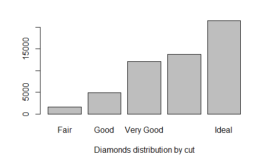

```r
plot(diamonds$cut, xlab="Diamonds distribution by cut")
```

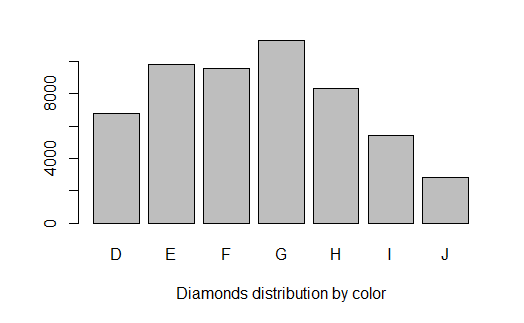

```r
plot(diamonds$color, xlab="Diamonds distribution by color")
```

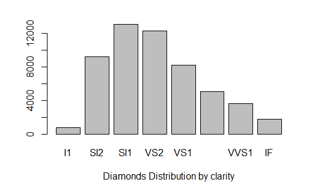

```r
plot(diamonds$clarity, xlab="Diamonds Distribution by clarity")
```

On retrouve bien graphiquement ce qui a été dit précédemment quand aux distributions des variables qualitatives.

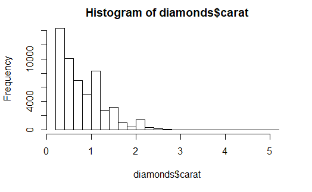

```r
hist(diamonds$carat,breaks=25)
```

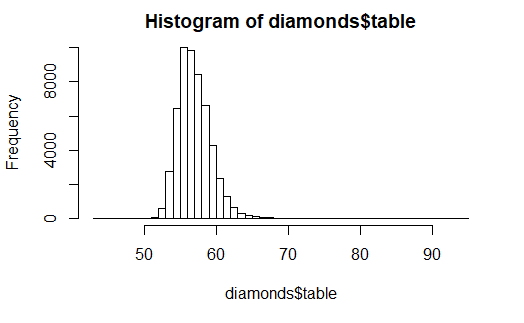

```r
hist(diamonds$table,breaks=50)
```

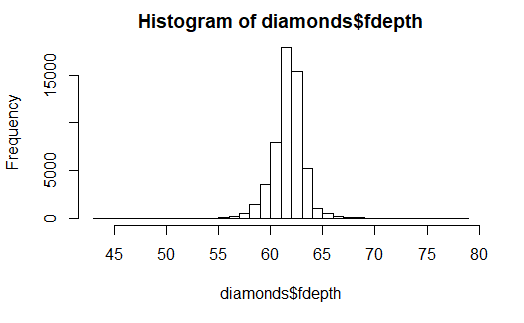

```r
hist(diamonds$fdepth,breaks=50)
```

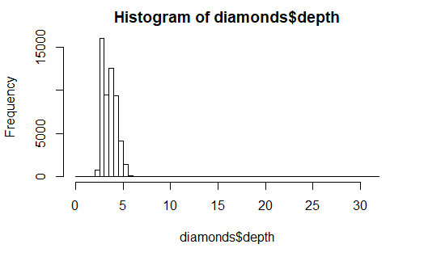

```r
hist(diamonds$depth,breaks=50)
```

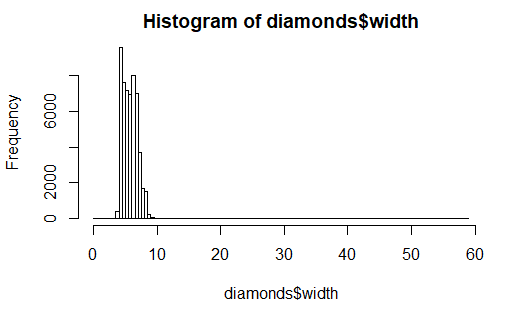

```r
hist(diamonds$width,breaks=100)
```

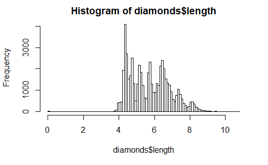

```r
hist(diamonds$length,breaks=100)
```

La majorité des diamants on des poids compris entre 0 et 2 carats. Les variables **table**, **fdepth**, **depth** et **width** ont des distributions Gaussiennes alors que la variable **length** pas du tout.

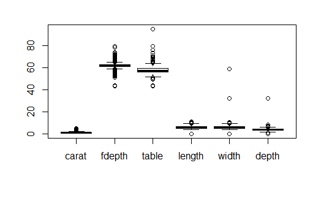

```r
boxplot(diamonds[,c(1,5,6,8,9,10)])
```

On remarque grâce à ce boxplot que les variables **fdepth** et **table** ont beaucop de points outliers. Les variables **width** et **depth** également mais dans une moindre mesure. On veillera dans la suite à mettre ces individus outliers en supplémentaire pour les utiliser lors de l’interprétation et non lors de l’apprentissage du modèle. (Il peut s’agir d’erreur de mesure)

## 3.2 Analyse de la variable **price**

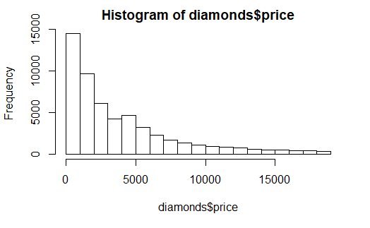

```r
hist(diamonds$price)
```

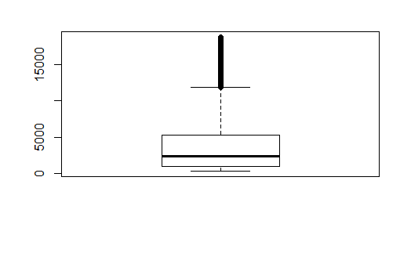

```r
boxplot(diamonds$price)
```

On remarque que la majorité des diamants de ce jeu de données ont des prix inférieurs à 10000 dollars et que ceux ayant un prix supérieur à 12000 dollars sont considérés comme outliers par le logiciel Rstudio. Il faudra donc porter un attention particulière à ces individus.

## 3.3 Etude des corrélations

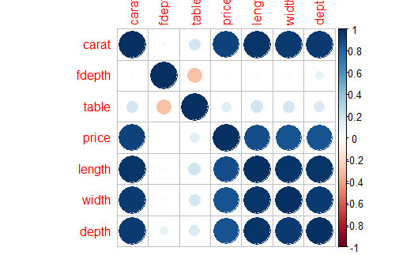

```r
corrplot(cor(diamonds[,-c(2,3,4)]))  #Corrélation des variables quantitatives
```

On remarque grâce à ce graphique des corrélations que les variables **price**, **length**, **width**, **depth** et **carat** sont très corrélées positivement. Le prix d’un diamant semble donc à première vu être déterminé par ses dimensions et son poids (en carat), en excluant les variables qualitatives de l’étude. De plus, on décèles une légère corrélation négative entre les variables **table** et **fdepth**.

```r
tab_cont1=table(diamonds$cut, diamonds$color)
chisq.test(tab_cont1)
```

```
    Pearson's Chi-squared test

data:  tab_cont1
X-squared = 310.32, df = 24, p-value < 2.2e-16
```

Au vu de la très faible p-value du test du khi-deux d’indépendance entre la variable **cut** et la variable **color**, on en déduit que ce deux variables ne sont pas indépendantes (on rejette Ho)

```r
tab_cont2=table(diamonds$cut, diamonds$clarity)
chisq.test(tab_cont2)
```

```
    Pearson's Chi-squared test

data:  tab_cont2
X-squared = 4391.4, df = 28, p-value < 2.2e-16
```

On obtient le même résultat ici, les variables **cut** et **clarity** ne sont pas indépendantes.

```r
tab_cont3=table(diamonds$color, diamonds$clarity)
chisq.test(tab_cont3)
```

```
    Pearson's Chi-squared test

data:  tab_cont3
X-squared = 2047.1, df = 42, p-value < 2.2e-16
```

Les variables **color** et **clarity** ne sont pas non plus indépendantes.

**Remarque** : Nous venons de montrer que les 3 variables qualitatives sont non-indépendantes et qu’il y beaucoup de corrélation entre les variables quantitatives explicatives. Cela nous posera surement des problèmes de modélisation et d’interprétation des résultast lors de nos différentes régressions futures.

# **4. Analyse en Composantes Principales**

## 4.1 Echantillonnage

```r
n=dim.data.frame(diamonds)[1]
Ind=seq.int(1,n,10)
data=diamonds[Ind,]           #On a donc un échantillon de 5394 observations, en prenant un                                    individus tous les 10 individus
data
```

| carat | cut | color | clarity | fdepth | table | price | length | width | depth |
| --- | --- | --- | --- | --- | --- | --- | --- | --- | --- |
| 0.23 | Ideal | E | SI2 | 61.5 | 55.0 | 326 | 3.95 | 3.98 | 2.43 |
| 0.30 | Good | J | SI1 | 64.0 | 55.0 | 339 | 4.25 | 4.28 | 2.73 |
| 0.30 | Good | I | SI2 | 63.3 | 56.0 | 351 | 4.26 | 4.30 | 2.71 |
| 0.23 | Very Good | F | VS1 | 60.0 | 57.0 | 402 | 4.00 | 4.03 | 2.41 |
| 0.33 | Ideal | I | SI2 | 61.2 | 56.0 | 403 | 4.49 | 4.50 | 2.75 |
| 0.24 | Very Good | F | SI1 | 60.9 | 61.0 | 404 | 4.02 | 4.03 | 2.45 |
| 0.35 | Ideal | I | VS1 | 60.9 | 57.0 | 552 | 4.54 | 4.59 | 2.78 |
| 0.24 | Very Good | D | VVS1 | 61.5 | 60.0 | 553 | 3.97 | 4.00 | 2.45 |
| 0.26 | Very Good | E | VVS1 | 63.4 | 59.0 | 554 | 4.00 | 4.04 | 2.55 |
| 0.70 | Ideal | E | SI1 | 62.5 | 57.0 | 2757 | 5.70 | 5.72 | 3.57 |

[output cut: 990 more lines]

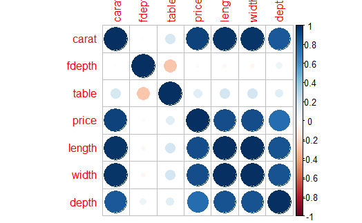

```r
corrplot(cor(data[,-c(2,3,4)]))
```

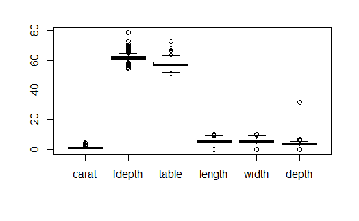

```r
boxplot(data[,c(1,5,6,8,9,10)])
```

On retrouve les mêmes corrélations entre variables quantitatives que sur le jeu de données complet à l’exception peut être d’une corrélation plus faible entre les variables **depth** et **price**. On a également diminué le nombre d’outliers. Il en reste néanmoins encore quelques uns que nous pourons éliminer lors de l’ACP.

## 4.2 ACP

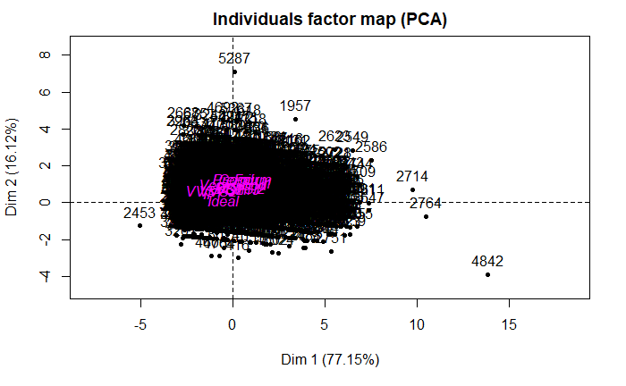

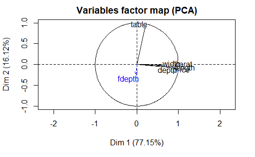

```r
data_acp=PCA(data,quali.sup=c(2,3,4),quanti.sup=5)
```

```r
#On met la variable fdepth en sup car c'est une fonction de length, width et depth
#on met également les 3 variables qualitatives en supplémentaire car l'ACP ne peut prendre en que de variables qualitatives.
```

### 4.2.1 Etude des individus

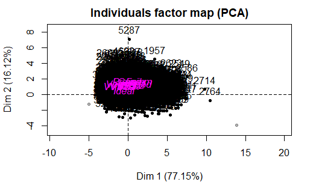

```r
plot.PCA(data_acp,choix="ind",select="cos2 0.7",unselect=0.7)
```

Nous voyons donc que 2 individus parmi la dizaine cités plus haut ont disparus de la représentation, nous les enlevons donc du modèle par la suite

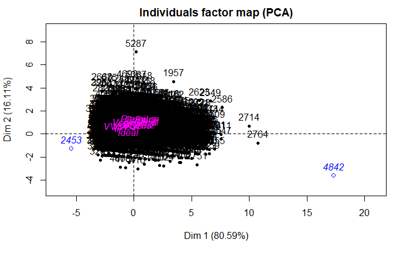

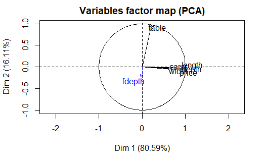

```r
data_acp_supp=PCA(data,quali.sup=c(2,3,4),quanti.sup=5, ind.sup=c(2453,4842))
```

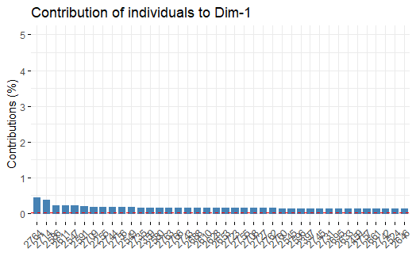

```r
fviz_contrib(data_acp_supp, choice = "ind", axes = 1, ylim=c(0,5), top=40)
```

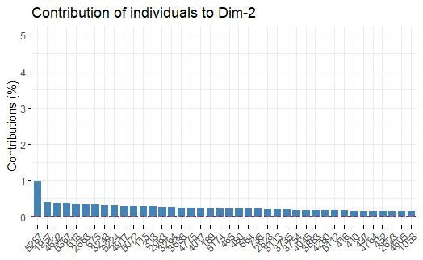

```r
fviz_contrib(data_acp_supp, choice = "ind", axes = 2, ylim=c(0,5), top=40)
```

Les individus 2764 et 2714 sont ceux qui contribuent le plus à la dimension 1, comme vu sur le nuage des individus précédemment. L’individu 5287 contribue le plus à l’axe 2, à hauteur d’1%, ce qui est très conséquent au vu de la taille de l’échantillon (5394 individus).

### ○ 4.2.2 Etude des variables

Le cercle des corrélations des variables montre que les varaibles **price**, **carat**, **depth**, **width** et **length** sont quasiment confonues. On retrouve ici la forte corrélation positive évoquée au début de l’analyse. De plus, ces variables sont très proches de l’axe 1 donc on en déduit que la dimension 1 met en oppostion les diamants ayant des prix élevés, une longueur, largeur et profondeur importantes et un poids (en carat) élevé aux diamants ayant un prix faible, une longueur, largeur, profondeur faible et un poids (en carat) faible. La variable **table** elle est quasiment orthogonale aux autres et contribue fortement à la dimension 2. On en déduit donc que la dimension 2 met en opppostion les diamants ayant une forte de valeur pour la variable **table** et ceux ayant une faible valeur. La variables quantitative supplémentaire **fdepth** est elle assez mal représentée sur le cercle, ce qui veut dire qu’elle ne contribuerait pas beacoup au plan constitué de la dimension 1 et 2. On retrouve par contre qu’elle est assez faiblement négativement corrélée avec la variable **table**.

Vérifions la contribution des variables aux différentes dimensions:

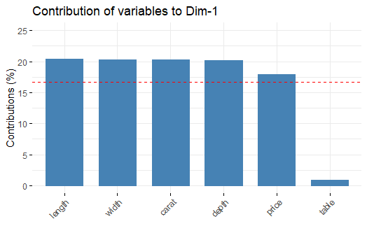

```r
fviz_contrib(data_acp_supp, choice = "var", axes = 1, ylim=c(0,25))
```

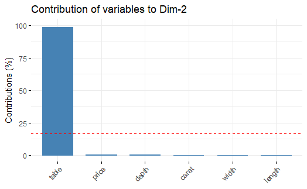

```r
fviz_contrib(data_acp_supp, choice = "var", axes = 2, ylim=c(0,100))
```

Comme prévu, les variables **length**, **width**, **carat**, **depth** et **price** contribuent chacunes à hauteur de 20% à la dimension 1. La variable table elle n’y contribue quasiment pas. En revanche, elle contribue énormément à la dimension 2.

### 4.2.3 Choix des axes

Regardons maintenant en fonction du pourcentage d’inertie projetée sur chaque axe combien de dimensions il faudrait garder dans la suite de l’étude.

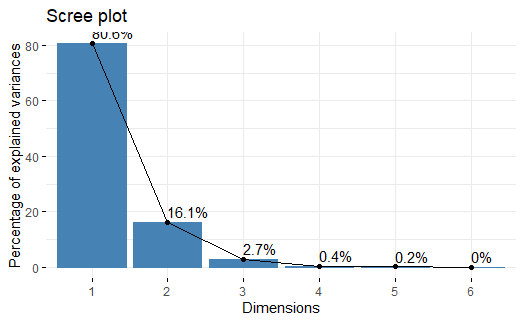

```r
fviz_eig(data_acp_supp, addlabels = TRUE)
```

On voit très clairement qu’une seule dimension explique déjà plus de 80% de l’information contenu dans le jeu de données. On prend donc très peu de risques en ne retenant qu’un axe et surtout on diminue grandement le nombre de variables explicatives.

Avec cette analyse sur Composantes Principales on pourrait donc conclure que pour expliquer le prix d’un diamant, il suffit de connaitre sa longueur, largeur, profondeur et poids. Et que plus un diamant est “lourd”, long, large et profond, plus son prix sera élevé.“en acp on n’expliuque pas une variable en fonction des autres, à clarifier”

Or, ces résulats ne prennent en compte que les variables quantitatives à notre disposition et si les variables qualitatives avaient également été prises en compte les résultats en seraient peut-être différents. D’ailleurs, si l’on regarde attentivement le nuage des individus, on pouura s’apercevoir que la modalité “Ideal” de la variable **cut** se trouve dans le cadran inférieur gauche, du coté des diamants au prix faible, et aux petites dimensions, ayant une valeur de **table** également fiable alors que c’est la coupe de diamant considérée comme étant la meilleure.

# **5. Analyse Factorielle multiple**

Ici il s’agit de prendre le jeu de données dans sa globalité et non en séparant données catégorielles et quantitatives. Pour effectuer une analyse factorielle multiple, les caractéristiques ds diamants de notre jeu de données doivent d’abord être regroupés selon ce qu’ils repésentent.

```r
#create groups for chracterizig each aspect of diamond
group_weight <- c("carat")
group_size <- c("length",
                "width",
                "depth"
)
group_physical_asp <- c("cut",
                        "color",
                        "clarity"
)
group_size_frequency <- c("fdepth",
                          "table"
)
```

D’un côté nous avons des mesures des diamnts à regrouper ensemble (même unité), d’un autre côté son poids. Nous avons aussi regroupés les caractéristiques qulitatives (aspects visuels) ainsi que les frequences et pourcentages.

Ceci étnt fait, nous pouvons commencer l’application de la méthode d’AFM.

```r
#change order of column by groups
data <- data[,c(group_weight,
                group_size,
                group_physical_asp,
                group_size_frequency)]
#MFa analysis
data_mfa <- MFA(data,
                         group      = c(1,3,3,2),
                         type       = c("c","s","n","s"),
                         name.group = c("weight",
                                        "size",
                                        "physical_aspects",
                                        "size_frequencies"
                         ),
                         graph=FALSE
)
##Standarder weight and size
#summary of analysis
summary(data_mfa)
```

```
Call:
MFA(base = data, group = c(1, 3, 3, 2), type = c("c", "s", "n",
     "s"), name.group = c("weight", "size", "physical_aspects",
     "size_frequencies"), graph = FALSE)


Eigenvalues
                       Dim.1   Dim.2   Dim.3   Dim.4   Dim.5   Dim.6   Dim.7   Dim.8   Dim.9  Dim.10  Dim.11  Dim.12  Dim.13  Dim.14  Dim.15
Variance               2.332   1.250   1.086   0.888   0.843   0.835   0.817   0.811   0.811   0.799   0.786   0.759   0.752   0.743   0.722
% of var.             13.724   7.353   6.390   5.226   4.960   4.913   4.808   4.772   4.769   4.703   4.624   4.467   4.424   4.373   4.250
Cumulative % of var.  13.724  21.077  27.467  32.693  37.654  42.567  47.375  52.147  56.916  61.619  66.243  70.710  75.134  79.507  83.757
                      Dim.16  Dim.17  Dim.18  Dim.19  Dim.20  Dim.21  Dim.22  Dim.23  Dim.24  Dim.25  Dim.26
Variance               0.690   0.679   0.559   0.478   0.255   0.079   0.020   0.000   0.000   0.000   0.000
% of var.              4.059   3.997   3.287   2.815   1.503   0.465   0.116   0.002   0.000   0.000   0.000
Cumulative % of var.  87.816  91.814  95.100  97.915  99.418  99.883  99.998 100.000 100.000 100.000 100.000

Groups
                    Dim.1    ctr   cos2    Dim.2    ctr   cos2    Dim.3    ctr   cos2
weight           |  0.889 38.126  0.791 |  0.022  1.737  0.000 |  0.028  2.570  0.001 |
size             |  0.884 37.910  0.779 |  0.020  1.590  0.000 |  0.031  2.816  0.001 |
physical_aspects |  0.457 19.574  0.020 |  0.460 36.821  0.020 |  0.740 68.134  0.051 |
size_frequencies |  0.102  4.390  0.008 |  0.748 59.852  0.424 |  0.288 26.480  0.063 |

Individuals (the 10 first)
                    Dim.1    ctr   cos2    Dim.2    ctr   cos2    Dim.3    ctr   cos2
1                | -1.905  0.029  0.270 |  0.343  0.002  0.009 | -0.437  0.003  0.014 |
2                | -0.937  0.007  0.030 |  1.175  0.020  0.046 |  1.469  0.037  0.073 |
3                | -0.694  0.004  0.020 |  0.689  0.007  0.020 |  1.021  0.018  0.044 |
4                | -1.822  0.026  0.213 | -1.133  0.019  0.082 |  0.204  0.001  0.003 |
5                | -0.918  0.007  0.057 |  0.434  0.003  0.013 | -0.897  0.014  0.054 |
6                | -1.325  0.014  0.119 | -1.582  0.037  0.169 |  1.504  0.039  0.153 |
7                | -1.236  0.012  0.102 |  0.075  0.000  0.000 | -0.922  0.015  0.057 |
8                | -2.175  0.038  0.192 | -1.239  0.023  0.062 |  1.088  0.020  0.048 |
9                | -2.175  0.038  0.209 | -0.464  0.003  0.010 |  1.232  0.026  0.067 |
10               | -0.492  0.002  0.032 |  0.623  0.006  0.052 |  0.083  0.000  0.001 |

Continuous variables
                    Dim.1    ctr   cos2    Dim.2    ctr   cos2    Dim.3    ctr   cos2
carat            |  0.448 38.126  0.889 |  0.070  1.737  0.022 | -0.079  2.570  0.028 |
length           |  0.944 13.559  0.891 |  0.105  0.314  0.011 | -0.184  1.101  0.034 |
width            |  0.940 13.453  0.884 |  0.108  0.329  0.012 | -0.191  1.189  0.036 |
depth            |  0.846 10.897  0.716 |  0.183  0.947  0.033 | -0.127  0.525  0.016 |
fdepth           | -0.012  0.005  0.000 |  0.709 31.450  0.503 |  0.425 13.018  0.181 |
table            |  0.362  4.385  0.131 | -0.674 28.401  0.454 |  0.432 13.462  0.187 |

Categories (the 10 first)
                     Dim.1     ctr    cos2  v.test     Dim.2     ctr    cos2  v.test     Dim.3     ctr    cos2  v.test
Fair             |   1.112   0.540   0.042   9.440 |   2.518   9.643   0.214  29.194 |   3.526  25.050   0.419  43.864 |
Good             |   0.423   0.212   0.019   6.079 |  -0.049   0.010   0.000  -0.965 |   1.196   7.831   0.155  25.209 |
Very Good        |   0.057   0.011   0.001   1.498 |  -0.268   0.830   0.027  -9.607 |   0.378   2.180   0.053  14.514 |
Premium          |   0.678   1.766   0.173  19.610 |  -1.016  13.795   0.387 -40.123 |   0.025   0.011   0.000   1.080 |
Ideal            |  -0.665   2.515   0.260 -25.744 |   0.659   8.601   0.255  34.853 |  -0.758  15.074   0.338 -43.010 |
D                |  -0.618   0.678   0.065 -11.116 |  -0.098   0.059   0.002  -2.405 |   0.422   1.458   0.030  11.125 |
E                |  -0.531   0.749   0.077 -12.114 |  -0.275   0.699   0.021  -8.569 |   0.267   0.871   0.019   8.915 |
F                |  -0.196   0.099   0.011  -4.399 |  -0.103   0.095   0.003  -3.155 |   0.196   0.455   0.010   6.422 |
G                |  -0.204   0.126   0.014  -5.048 |   0.125   0.164   0.005   4.216 |  -0.260   0.947   0.022  -9.447 |
H                |   0.528   0.599   0.060  10.609 |   0.121   0.110   0.003   3.324 |  -0.209   0.431   0.009  -6.139 |
```

```r
#inertia and eigen values
data_mfa$eig
```

```
          eigenvalue percentage of variance cumulative percentage of variance
comp 1  2.332262e+00           1.372364e+01                          13.72364
comp 2  1.249646e+00           7.353241e+00                          21.07688
comp 3  1.085920e+00           6.389836e+00                          27.46672
comp 4  8.882140e-01           5.226483e+00                          32.69320
comp 5  8.429820e-01           4.960326e+00                          37.65353
comp 6  8.349911e-01           4.913306e+00                          42.56683
comp 7  8.170572e-01           4.807778e+00                          47.37461
comp 8  8.109868e-01           4.772058e+00                          52.14667
comp 9  8.105055e-01           4.769226e+00                          56.91589
comp 10 7.992094e-01           4.702757e+00                          61.61865
comp 11 7.858716e-01           4.624274e+00                          66.24292
comp 12 7.592018e-01           4.467342e+00                          70.71027
comp 13 7.517835e-01           4.423690e+00                          75.13396
comp 14 7.432222e-01           4.373314e+00                          79.50727
comp 15 7.222459e-01           4.249884e+00                          83.75715
comp 16 6.898060e-01           4.058999e+00                          87.81615
comp 17 6.793411e-01           3.997420e+00                          91.81357
comp 18 5.585726e-01           3.286787e+00                          95.10036
comp 19 4.783980e-01           2.815019e+00                          97.91538
comp 20 2.553646e-01           1.502632e+00                          99.41801
comp 21 7.898246e-02           4.647534e-01                          99.88276
comp 22 1.963877e-02           1.155597e-01                          99.99832
comp 23 2.849161e-04           1.676521e-03                         100.00000
comp 24 1.045826e-29           6.153913e-29                         100.00000
comp 25 4.399142e-30           2.588570e-29                         100.00000
comp 26 2.501763e-30           1.472103e-29                         100.00000
```

Avec 2 comp on n’explique que 21% de la variance. Pour avoir un pourcentage 50% il faudrait prendre au minimum 8 composantes. Pour des raisons pratiques on va se limiter à deux composantes principales. Regardons de plus près comment ces deux axes sont constituées, du point de vue des groupes, puis variables et enfin des individus.

## 5.1 Information des groupes

```r
#extract all important info according to groups and not variables only
groups_mfa_results <- get_mfa_var(data_mfa, "group")
#show all
groups_mfa_results$coord
```

```
                     Dim.1      Dim.2      Dim.3        Dim.4        Dim.5
weight           0.8891917 0.02170358 0.02790663 6.246012e-05 0.0022890914
size             0.8841562 0.01987498 0.03057574 7.316851e-04 0.0034314530
physical_aspects 0.4565283 0.46013413 0.73988425 8.716832e-01 0.8367706697
size_frequencies 0.1023858 0.74793295 0.28755314 1.573672e-02 0.0004907428
```

We can already notice than for the first dimension weight, size, physical aspects are mainly used for 1st dimension. For the y axis, the group of size frequencies are used most.

Let us show the synthetic variables created in order to represent the groups from the information

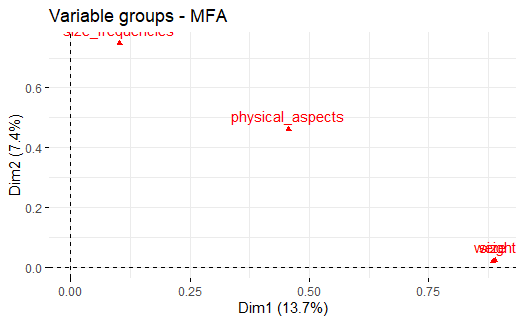

```r
fviz_mfa_var(data_mfa, "group")
```

As mentioned above the weight and size variables are practically the same. These are also positively correlated. The synthetic variable physical_aspects seems to be mildly correlated with both size and frequencies. However, frequencies seems to be completely uncolerelated to the rest of the groups.

## 5.2 Information des variables

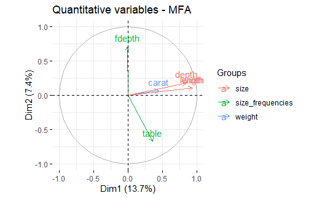

```r
fviz_mfa_var(data_mfa)
```

## 5.3 information des individus

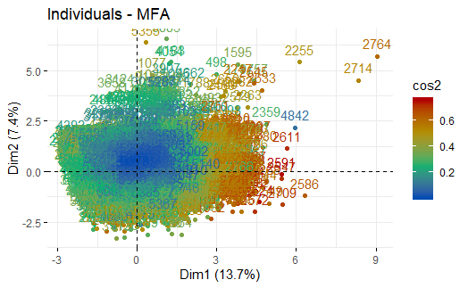

```r
fviz_mfa_ind(data_mfa, col.ind = "cos2", gradient.cols=c("#024cb2","#02b26f","#b29002","#b20202"))
```

Individuals gathered auround the center seem to be the worst represented. However, the individuals ont the 1 axis rather on the outside seem to be best represented.

On the second axis, it sems the individuals are bddly epresented. This may stem from the fact that several axis should be added.

## 5.4 Contributions

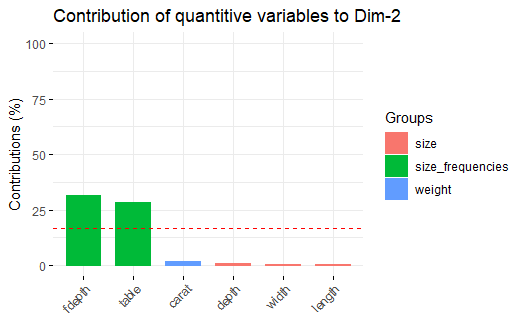

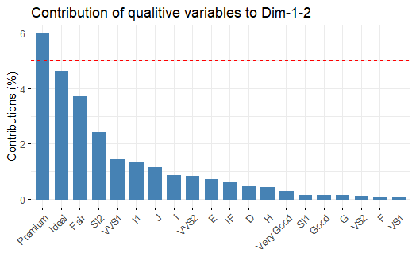

Les variables qualitatives contribuent très très peu à l’ensemble. Hormis la variable cut qui a tendance à contribuer le plus. Les individus synthétique créée à partir des individus de type Premium cut, ont l’air de contribuer le plus. Cependant le reste peut être considéré comme négligeable.

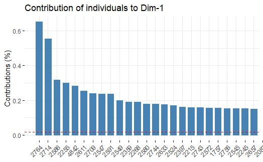

Contrary to the pca analysis, no individuals stand out with the same amplitude.

```r
dimdesc(data_mfa)
```

[output not shown]